# Problem statement - Term Deposit Subcription

# Objective

Using the data collected from existing customers, build a model that will help the marketing team identify potential customers who are relatively more likely to subscribe term deposit and thus increase their hit ratio.

## What is a Term Deposit?

A Term deposit is a deposit that a bank or a financial institution offers with a fixed rate (often better than just opening deposit account) in which your money will be returned back at a specific maturity time.

# Data Description:

### Bank client data:

1. age: Continuous feature
2. job: Type of job (management, technician, entrepreneur, blue-collar, etc.)
3. marital: marital status (married, single, divorced)
4. education: education level (primary, secondary, tertiary)
5. default: has credit in default?
6. housing: has housing loan?
7. loan: has personal loan?
8. balance in account

### Related to previous contact:

1. contact: contact communication type
2. month: last contact month of year
3. day: last contact day of the month
4. duration: last contact duration, in seconds*

### Other attributes:

1. campaign: number of contacts performed during this campaign and for this client
2. pdays: number of days that passed by after the client was last contacted from a previous campaign (-1 tells us the person has not been contacted or contact period is beyond 900 days)
3. previous: number of contacts performed before this campaign and for this client
4. poutcome: outcome of the previous marketing campaign Output variable (desired target):
5. Target: Tell us has the client subscribed a term deposit. (Yes, No)

## `Index`

- Import Libraries and Load Dataset
- EDA - Univariate & Bivariate Analysis
- Preparing the Data for Analsyis
- Logistic Regression
- Decision Tree
- Feature Engineering with - Grid Search
- Random Forest Classifier Algorithm
- Bagging Classifier Algorithm
- Adaboost Ensemble Algorithm
- GradientBoost Ensemble Algorithm

# Import Libraries & Load Dataset

```python
#IMPORTING LIBRARY
import numpy as np
import pandas as pd
import seaborn as sns
import matplotlib.pyplot as plt
import warnings
warnings.filterwarnings('ignore')

from sklearn.linear_model import LogisticRegression
from sklearn.model_selection import train_test_split, GridSearchCV, cross_validate
from sklearn.tree import DecisionTreeClassifier
from sklearn.metrics import accuracy_score, f1_score, recall_score,roc_auc_score, precision_score, confusion_matrix, classification_report

from yellowbrick.classifier import ClassificationReport, ROCAUC
```

```python
#IMPORTING DATA
pdata = pd.read_csv('bank-full.csv')
pdata.head()
```

|  | age | job | marital | education | default | balance | housing | loan | contact | day | month | duration | campaign | pdays | previous | poutcome | Target |
| --- | --- | --- | --- | --- | --- | --- | --- | --- | --- | --- | --- | --- | --- | --- | --- | --- | --- |
| 0 | 58 | management | married | tertiary | no | 2143 | yes | no | unknown | 5 | may | 261 | 1 | -1 | 0 | unknown | no |
| 1 | 44 | technician | single | secondary | no | 29 | yes | no | unknown | 5 | may | 151 | 1 | -1 | 0 | unknown | no |
| 2 | 33 | entrepreneur | married | secondary | no | 2 | yes | yes | unknown | 5 | may | 76 | 1 | -1 | 0 | unknown | no |
| 3 | 47 | blue-collar | married | unknown | no | 1506 | yes | no | unknown | 5 | may | 92 | 1 | -1 | 0 | unknown | no |
| 4 | 33 | unknown | single | unknown | no | 1 | no | no | unknown | 5 | may | 198 | 1 | -1 | 0 | unknown | no |

```python
#Checking missing values
pdata.isnull().sum()
```

```
age          0
job          0
marital      0
education    0
default      0
balance      0
housing      0
loan         0
contact      0
day          0
month        0
duration     0
campaign     0
pdays        0
previous     0
poutcome     0
Target       0
dtype: int64
```

```python
# Data Type
pdata.dtypes
```

```
age           int64
job          object
marital      object
education    object
default      object
balance       int64
housing      object
loan         object
contact      object
day           int64
month        object
duration      int64
campaign      int64
pdays         int64
previous      int64
poutcome     object
Target       object
dtype: object
```

```python
# Data Info
pdata.info()
```

```
<class 'pandas.core.frame.DataFrame'>
RangeIndex: 45211 entries, 0 to 45210
Data columns (total 17 columns):
 #   Column     Non-Null Count  Dtype
---  ------     --------------  -----
 0   age        45211 non-null  int64
 1   job        45211 non-null  object
 2   marital    45211 non-null  object
 3   education  45211 non-null  object
 4   default    45211 non-null  object
 5   balance    45211 non-null  int64
 6   housing    45211 non-null  object
 7   loan       45211 non-null  object
 8   contact    45211 non-null  object
 9   day        45211 non-null  int64
 10  month      45211 non-null  object
 11  duration   45211 non-null  int64
 12  campaign   45211 non-null  int64
 13  pdays      45211 non-null  int64
 14  previous   45211 non-null  int64
 15  poutcome   45211 non-null  object
 16  Target     45211 non-null  object
dtypes: int64(7), object(10)
memory usage: 5.9+ MB
```

```python
#Check for zeros
(pdata[:][:] == 0).sum()
```

```
age              0
job              0
marital          0
education        0
default          0
balance       3514
housing          0
loan             0
contact          0
day              0
month            0
duration         3
campaign         0
pdays            0
previous     36954
poutcome         0
Target           0
dtype: int64
```

```python
#Number of Unique data
pdata.nunique()
```

```
age            77
job            12
marital         3
education       4
default         2
balance      7168
housing         2
loan            2
contact         3
day            31
month          12
duration     1573
campaign       48
pdays         559
previous       41
poutcome        4
Target          2
dtype: int64
```

```python
#Check for negative values
print((pdata[:]['balance'] < 0).sum())
print((pdata[:]['pdays'] < 0).sum())
print((pdata[:]['previous'] < 0).sum())
```

```
3766
36954
0
```

```python
pdata.describe().T
```

|  | count | mean | std | min | 25% | 50% | 75% | max |
| --- | --- | --- | --- | --- | --- | --- | --- | --- |
| age | 45211.0 | 40.936210 | 10.618762 | 18.0 | 33.0 | 39.0 | 48.0 | 95.0 |
| balance | 45211.0 | 1362.272058 | 3044.765829 | -8019.0 | 72.0 | 448.0 | 1428.0 | 102127.0 |
| day | 45211.0 | 15.806419 | 8.322476 | 1.0 | 8.0 | 16.0 | 21.0 | 31.0 |
| duration | 45211.0 | 258.163080 | 257.527812 | 0.0 | 103.0 | 180.0 | 319.0 | 4918.0 |
| campaign | 45211.0 | 2.763841 | 3.098021 | 1.0 | 1.0 | 2.0 | 3.0 | 63.0 |
| pdays | 45211.0 | 40.197828 | 100.128746 | -1.0 | -1.0 | -1.0 | -1.0 | 871.0 |
| previous | 45211.0 | 0.580323 | 2.303441 | 0.0 | 0.0 | 0.0 | 0.0 | 275.0 |

**Insights**

- We have 45211 records with 17 attributes (Data types: 10 Objective and 7 Integers)
- There is no null values in all 17 attributes.
- Dependent variable is obviously "Target"
- 31 days are very normal and no anamolies found
- 12 months are very normal and no anamolies found
- The following object needs to be convert into intergers (job, maritial, education, default, housing, loan, contact, month, poutcome, Target)
- Balance - 3514 accounts has 0 balances and 3766 accounts has negative balances. For statement balances its absolutely fine to go negative and zero so I am going to retain as it is.
- Previous - has 36954 zeros needs to be treated.
- pday - has 36954 negatives needs to be treated.
- Describe only works for numeric variables, going to ignore at this point.
- We can see that the data for two classes in the target variable is imbalanced.
- 'default' column has majority of values (approx 98%) as 'no'. We can drop this column as it won't provide much information for the model.
- Columns like - jobs and poutcome have 'unknown' values. We can either drop it, but then we will lose data as poutcome have approx 81% 'unknown' values. So, we are going to treat 'unknown' as separate category.

# EDA - Univeriate & Bivariate Analysis

```
AGE :
```

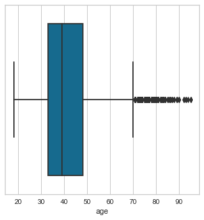

```
BALANCE :
```

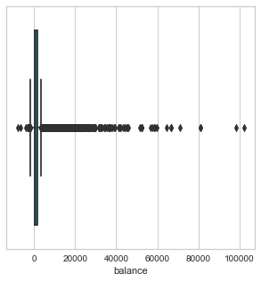

```
DAY :
```

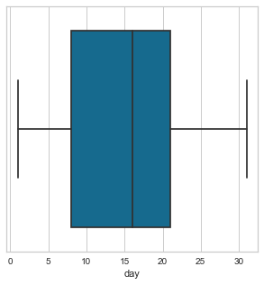

```
DURATION :
```

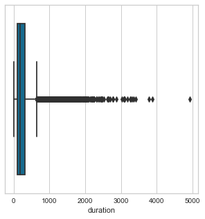

```
CAMPAIGN :
```

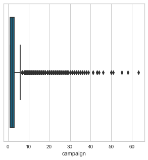

```
PDAYS :
```

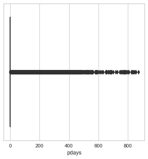

```
PREVIOUS :
```

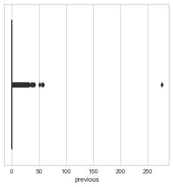

```python
#Box plot
for i in pdata.columns[pdata.dtypes=='int64']:
    print(i.upper(),":")
    plt.figure(figsize=(5,5))
    sns.boxplot(x=pdata[i])
    plt.show()
```

```
Degree of Relationship with Dependent Variable :
```

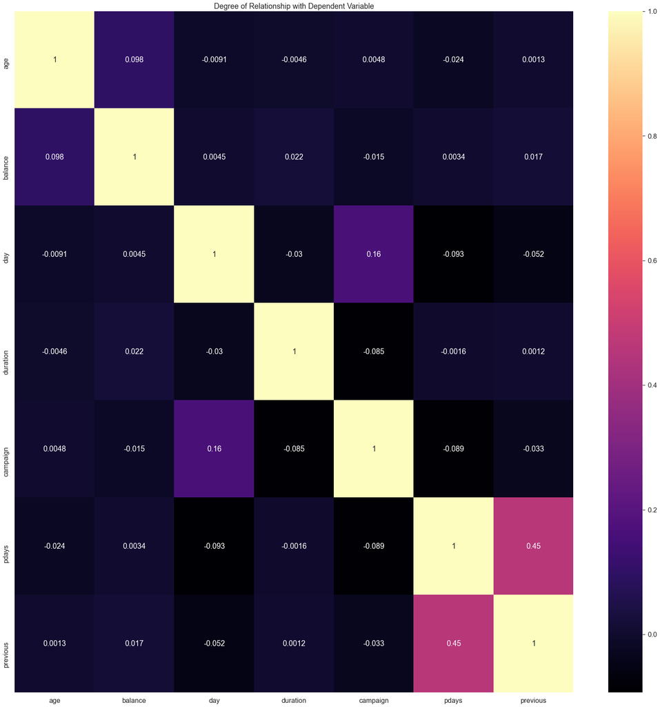

```python
#Heatmap to consider the relations
k=pdata.corr()
plt.figure (figsize=(30,30))
print('Degree of Relationship with Dependent Variable : ')
sns.set(font_scale=1.5)
sns.heatmap(k, annot=True, cmap='magma').set_title('Degree of Relationship with Dependent Variable')
plt.show()
```

```
AGE  :
```

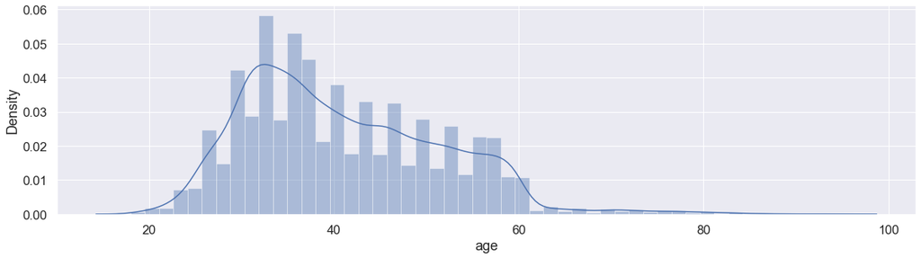

```
BALANCE  :
```

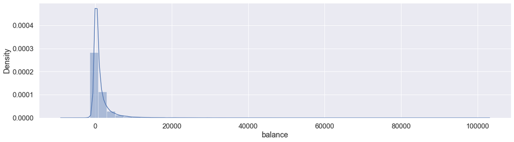

```
DAY  :
```

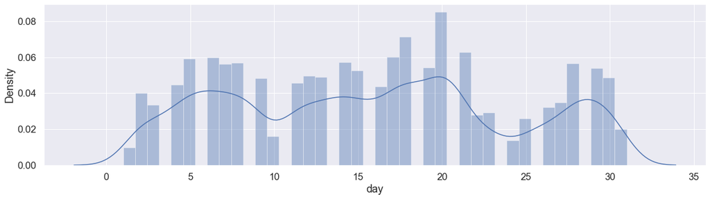

```
DURATION  :
```

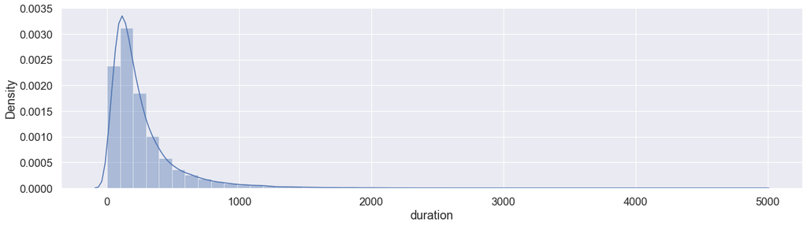

```
CAMPAIGN  :
```

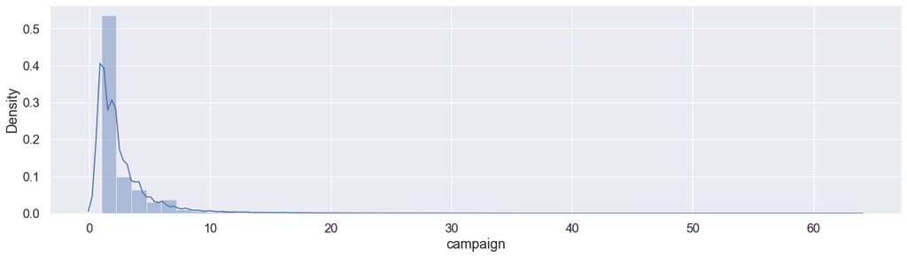

```
PDAYS  :
```

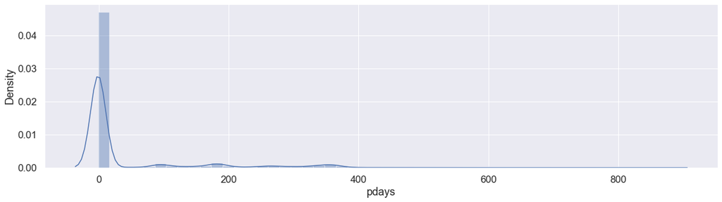

```
PREVIOUS  :
```

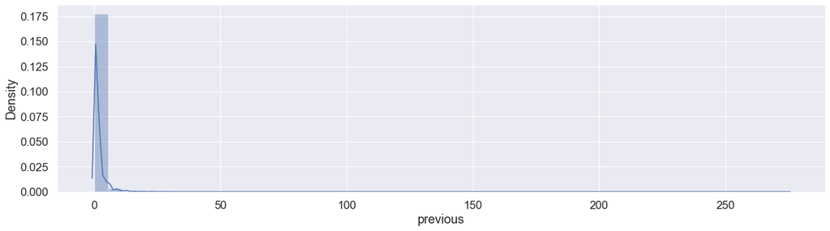

```
JOB  :
```

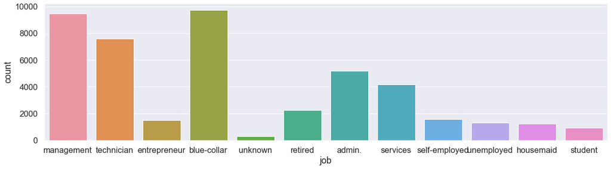

```
MARITAL  :
```

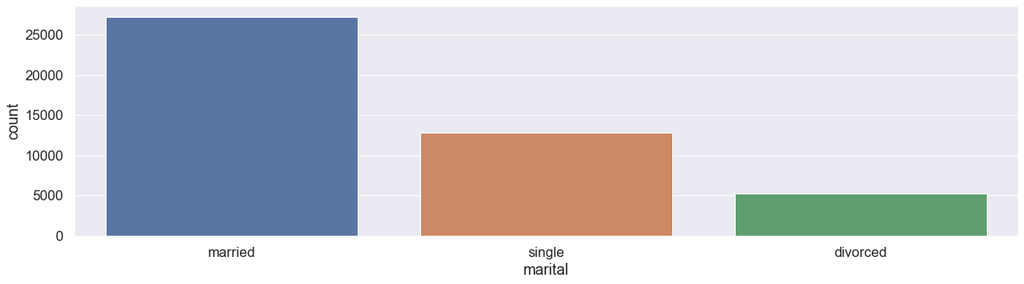

```
EDUCATION  :
```

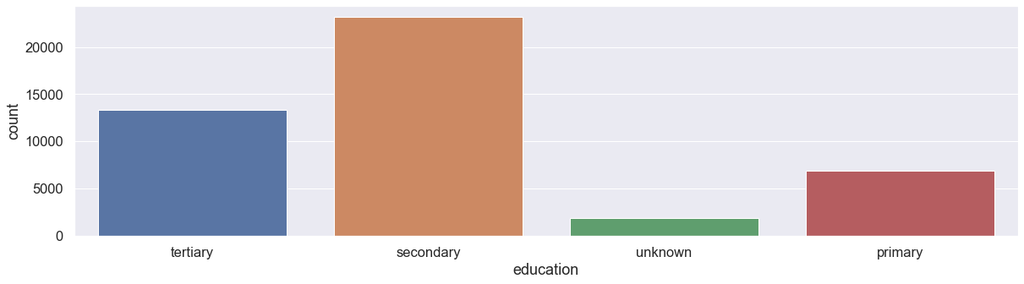

```
DEFAULT  :
```

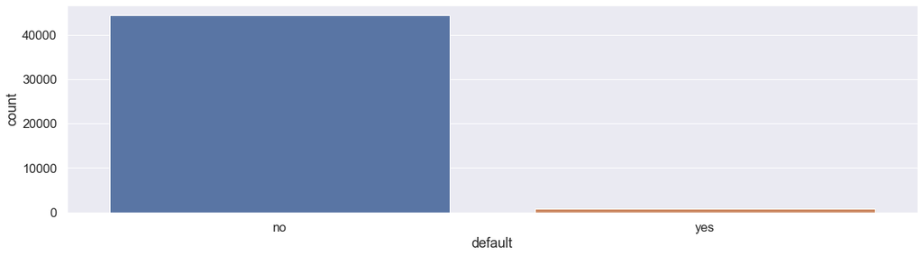

```
HOUSING  :
```

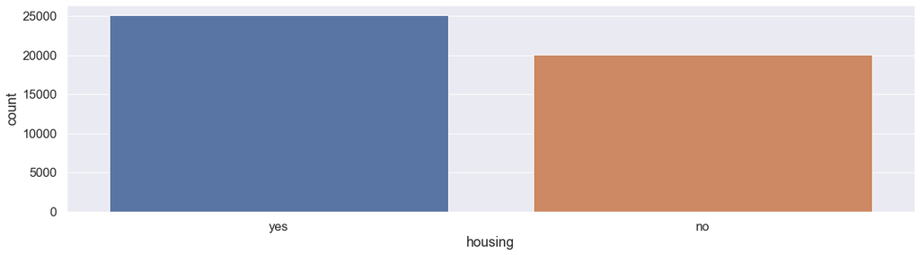

```
LOAN  :
```

[5 more figures not shown]

```python
#Multivariate Analysis

for i in pdata.columns[pdata.dtypes=='int64']:
    plt.figure(figsize=(20,5))
    print(i.upper()," : ")
    sns.distplot(pdata[i])
    plt.show()

for i in pdata.columns[pdata.dtypes=='object']:
    plt.figure(figsize=(20,5))
    print(i.upper()," : ")
    sns.countplot(pdata[i])
    plt.show()
```

**Insights**